# balamurugan_nagasoundari_ps04

### 1.3 Implement The 2D Version

**1. What's the location of the true minimum of f(x)?**  
*The location of true minimum changes with different start value, though its approximately [0,0].*

```python
## This function can be used to check the true minimum
#optimize.minimize(f2D, [2, -3], method="CG") #--Parameters to be passed: function name, start value
```

```python
x = np.array([[2], [-3]])
A = np.array([[1,0],[0,1]])

print("The eigen values are ", np.linalg.eig(A)[0])
```

```
The eigen values are  [ 1.  1.]
```

```python
## Function
def f2D(x):
    r = x.T @ A @ x
    return r


## Gradient function
def gradientf2D(x):
    r = 2 * A @ x
    return r

x = np.array([[2], [-3]])

gradientf2D(x)
```

```
array([[ 4],
       [-6]])
```

#### 1.3.5 Implementation of 2D GD algorithm

```python
cur_x = np.array([[2], [-3]]) ##Starting value of x
stopping_criterion_e = 0.01 ##This tells us when to stop the algorithm
iters = 0 #Initial number of iterations
max_iters = 1000 ##Maximum number of iterations
rate = 0.01  ##Learning rate


## function to implement 2D gradient function
def implement_gradient_2D(cur_x, iters, max_iters, rate):
    while np.linalg.norm(gradientf2D(cur_x)) > stopping_criterion_e and iters < max_iters:
        print("Norm val is ", np.linalg.norm(gradientf2D(cur_x)))
        prev_x = cur_x #Store current x value in prev_x
        cur_x = cur_x - rate * gradientf2D(prev_x) #Grad descent
        iters = iters + 1 #iteration count
        print("Iteration", iters, "\nX value is ", prev_x, "\nf(x) value is ", f2D(prev_x), "\nGradient value is ", gradientf2D(prev_x))
    print("The solution is ", prev_x, " and it took ", iters, " iterations")


implement_gradient_2D(cur_x, iters, max_iters, rate)
```

```
Norm val is  7.21110255093
Iteration 1
X value is  [[ 2]
 [-3]]
f(x) value is  [[13]]
Gradient value is  [[ 4]
 [-6]]
Norm val is  7.06688049991
Iteration 2
X value is  [[ 1.96]
 [-2.94]]
f(x) value is  [[ 12.4852]]
Gradient value is  [[ 3.92]
 [-5.88]]
Norm val is  6.92554288991
Iteration 3
X value is  [[ 1.9208]
 [-2.8812]]
f(x) value is  [[ 11.99078608]]
Gradient value is  [[ 3.8416]
 [-5.7624]]
Norm val is  6.78703203211
Iteration 4
X value is  [[ 1.882384]
 [-2.823576]]
f(x) value is  [[ 11.51595095]]
Gradient value is  [[ 3.764768]
 [-5.647152]]
Norm val is  6.65129139147
Iteration 5
X value is  [[ 1.84473632]
 [-2.76710448]]
f(x) value is  [[ 11.05991929]]
Gradient value is  [[ 3.68947264]
 [-5.53420896]]
Norm val is  6.51826556364
Iteration 6
X value is  [[ 1.80784159]
 [-2.71176239]]
f(x) value is  [[ 10.62194649]]
```

[output cut: 2229 more lines]

```
Iteration 325
X value is  [[ 0.00287262]
 [-0.00430893]]
f(x) value is  [[  2.68188654e-05]]
Gradient value is  [[ 0.00574524]
 [-0.00861787]]
Norm val is  0.0101502390819
Iteration 326
X value is  [[ 0.00281517]
 [-0.00422275]]
f(x) value is  [[  2.57568384e-05]]
Gradient value is  [[ 0.00563034]
 [-0.00844551]]
The solution is  [[ 0.00281517]
 [-0.00422275]]  and it took  326  iterations
```

#### 1.3.6 Visualize the 2D plot

```python
def plot_graph(startpt, nsteps, lrate):
    x1range = [-3,3]
    x2range = [-3,3]

    ex1 = np.linspace(x1range[0], x1range[1], 30)
    ex2 = np.linspace(x2range[0], x2range[1], 30)
    (xm1, xm2) = np.meshgrid(ex1, ex2)
    x1 = xm1.ravel()
    x2 = xm2.ravel()
    z = np.empty_like(xm1)
    for i in range(30):
        for j in range(30):
            x = np.array((xm1[i,j], xm2[i,j]))
            z[i,j] = f2D(x)

    fig = plt.figure(figsize = [10,10])
    ax = fig.add_subplot(111)
    ax.set_aspect('equal')  # ensure equal aspect ratio
    cs = ax.contour(ex1, ex2, z) # make contour plot
    ax.clabel(cs, inline=1)  # add contour values

    # starting point
    a0 = startpt[0]; a1 = startpt[1]
    ax.plot(a0,a1, 'o')
    #print(a0,a1)

    # do the gradient descent loop and plot the progress
    for i in range(nsteps):
        a0old, a1old = a0, a1
        startpt = np.matrix(startpt).reshape(2,1) - lrate * gradientf2D(np.matrix(startpt).reshape(2,1))
        a0 = startpt.item(0); a1 = startpt.item(0)
        #print(a0, a1) # the updated parameters
        ax.plot(a0,a1,'o')
        ax.plot([a0old,a0],[a1old,a1], '-') # connect the dots

    plt.show()
```

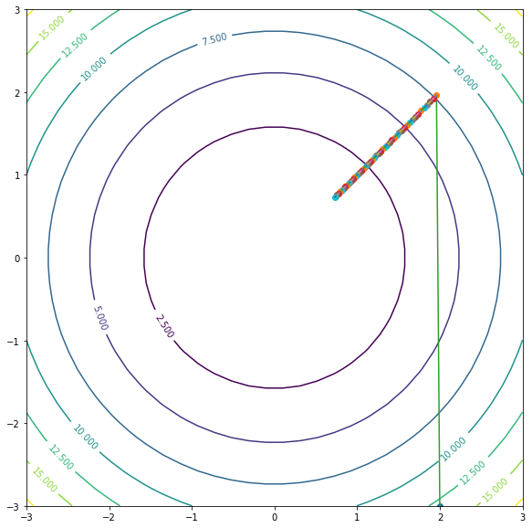

```python
x = np.array([[2], [-3]])
A = np.array([[1,0],[0,1]])
plot_graph([2,-3], 50, 0.01) #Arguments passed startpt, nsteps(no of points to be shown), learningrate
```

From the above plot, we could see that the starting point is (2,-3) marked by the green line. The learning rate is set to 0.01. As we progress we could see that the point converges towards the center of the circles(location minimum). As we have stopped after 50 steps, the graph reached closer to the minimum point.

#### 1.3.7 Experimentation with different learning rates

```
Norm val is  7.21110255093
Iteration 1
X value is  [[ 2]
 [-3]]
f(x) value is  [[13]]
Gradient value is  [[ 4]
 [-6]]
Norm val is  6.48999229584
Iteration 2
X value is  [[ 1.8]
 [-2.7]]
f(x) value is  [[ 10.53]]
Gradient value is  [[ 3.6]
 [-5.4]]
Norm val is  5.84099306625
Iteration 3
X value is  [[ 1.62]
 [-2.43]]
f(x) value is  [[ 8.5293]]
Gradient value is  [[ 3.24]
 [-4.86]]
Norm val is  5.25689375963
Iteration 4
X value is  [[ 1.458]
 [-2.187]]
f(x) value is  [[ 6.908733]]
Gradient value is  [[ 2.916]
 [-4.374]]
Norm val is  4.73120438366
Iteration 5
X value is  [[ 1.3122]
 [-1.9683]]
f(x) value is  [[ 5.59607373]]
Gradient value is  [[ 2.6244]
 [-3.9366]]
Norm val is  4.2580839453
Iteration 6
X value is  [[ 1.18098]
 [-1.77147]]
f(x) value is  [[ 4.53281972]]
```

[output cut: 388 more lines]

```
Iteration 62
X value is  [[ 0.00323462]
 [-0.00485193]]
f(x) value is  [[  3.40039606e-05]]
Gradient value is  [[ 0.00646924]
 [-0.00970386]]
Norm val is  0.0104963247018
Iteration 63
X value is  [[ 0.00291116]
 [-0.00436674]]
f(x) value is  [[  2.75432081e-05]]
Gradient value is  [[ 0.00582231]
 [-0.00873347]]
The solution is  [[ 0.00291116]
 [-0.00436674]]  and it took  63  iterations
```

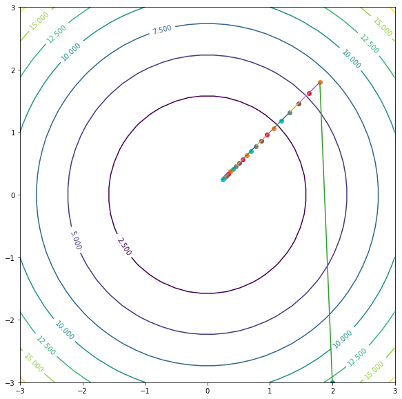

```python
x = np.array([[2], [-3]])
A = np.array([[1,0],[0,1]])
#print(np.linalg.eig(A)[0])
implement_gradient_2D(x, 0, 1000, 0.05)
plot_graph([2,-3], 20, 0.05) #Arguments passed startpt, nsteps, learningrate
```

```
Norm val is  7.21110255093
Iteration 1
X value is  [[ 2]
 [-3]]
f(x) value is  [[13]]
Gradient value is  [[ 4]
 [-6]]
Norm val is  5.76888204074
Iteration 2
X value is  [[ 1.6]
 [-2.4]]
f(x) value is  [[ 8.32]]
Gradient value is  [[ 3.2]
 [-4.8]]
Norm val is  4.61510563259
Iteration 3
X value is  [[ 1.28]
 [-1.92]]
f(x) value is  [[ 5.3248]]
Gradient value is  [[ 2.56]
 [-3.84]]
Norm val is  3.69208450608
Iteration 4
X value is  [[ 1.024]
 [-1.536]]
f(x) value is  [[ 3.407872]]
Gradient value is  [[ 2.048]
 [-3.072]]
Norm val is  2.95366760486
Iteration 5
X value is  [[ 0.8192]
 [-1.2288]]
f(x) value is  [[ 2.18103808]]
Gradient value is  [[ 1.6384]
 [-2.4576]]
Norm val is  2.36293408389
Iteration 6
X value is  [[ 0.65536]
 [-0.98304]]
f(x) value is  [[ 1.39586437]]
```

[output cut: 157 more lines]

```
Iteration 29
X value is  [[ 0.00386856]
 [-0.00580284]]
f(x) value is  [[  4.86387745e-05]]
Gradient value is  [[ 0.00773713]
 [-0.01160569]]
Norm val is  0.011158640719
Iteration 30
X value is  [[ 0.00309485]
 [-0.00464228]]
f(x) value is  [[  3.11288157e-05]]
Gradient value is  [[ 0.0061897 ]
 [-0.00928455]]
The solution is  [[ 0.00309485]
 [-0.00464228]]  and it took  30  iterations
```

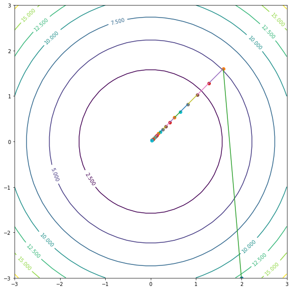

```python
x = np.matrix([[2], [-3]])
A = np.matrix([[1,0],[0,1]])
implement_gradient_2D(x, 0, 1000, 0.1)
plot_graph([2,-3], 20, 0.1) #Arguments passed startpt, nsteps, learningrate
```

**From the above 3 graphs, we could see that increasing the learning rate makes the convergence happen faster with less number of steps.**

#### 1.3.8 Implementation of 5D algorithm

```python
A = np.arange(25).reshape(5,5) + 1
I = np.identity(5)

A = 0.5 * (A + A.T) + 10 * I
x = np.array([[10], [20], [30], [40], [50]])

iters = 0
max_iters = 1000
rate = 0.01
implement_gradient_2D(x, iters, max_iters, rate)
```

```
Norm val is  11922.6674868
Iteration 1
X value is  [[10]
 [20]
 [30]
 [40]
 [50]]
f(x) value is  [[ 437500.]]
Gradient value is  [[ 2900.]
 [ 4000.]
 [ 5100.]
 [ 6200.]
 [ 7300.]]
Norm val is  7466.29091316
Iteration 2
X value is  [[-19.]
 [-20.]
 [-21.]
 [-22.]
 [-23.]]
f(x) value is  [[ 171775.]]
Gradient value is  [[-1910.]
 [-2560.]
 [-3210.]
 [-3860.]
 [-4510.]]
Norm val is  4675.74753382
Iteration 3
X value is  [[  0.1]
 [  5.6]
 [ 11.1]
 [ 16.6]
 [ 22.1]]
f(x) value is  [[ 67543.75]]
Gradient value is  [[ 1109.]
 [ 1552.]
 [ 1995.]
 [ 2438.]
 [ 2881.]]
Norm val is  2928.39248565
```

[output cut: 1484 more lines]

```
 [-0.00061318]
 [-0.00018157]
 [ 0.00025003]
 [ 0.00068164]]
f(x) value is  [[  7.48127453e-06]]
Gradient value is  [[-0.00770962]
 [-0.00452474]
 [-0.00133986]
 [ 0.00184501]
 [ 0.00502989]]
The solution is  [[-0.00104479]
 [-0.00061318]
 [-0.00018157]
 [ 0.00025003]
 [ 0.00068164]]  and it took  118  iterations
```

```python
A = np.arange(25).reshape(5,5) + 1
I = np.identity(5)

A = 0.5 * (A + A.T) + 10 * I
x = np.array([[10], [20], [30], [40], [50]])

iters = 0
max_iters = 1000
rate = 0.005
implement_gradient_2D(x, iters, max_iters, rate)
```

```
Norm val is  11922.6674868
Iteration 1
X value is  [[10]
 [20]
 [30]
 [40]
 [50]]
f(x) value is  [[ 437500.]]
Gradient value is  [[ 2900.]
 [ 4000.]
 [ 5100.]
 [ 6200.]
 [ 7300.]]
Norm val is  2229.65804553
Iteration 2
X value is  [[ -4.5]
 [  0. ]
 [  4.5]
 [  9. ]
 [ 13.5]]
f(x) value is  [[ 15693.75]]
Gradient value is  [[  495.]
 [  720.]
 [  945.]
 [ 1170.]
 [ 1395.]]
Norm val is  423.424653864
Iteration 3
X value is  [[-6.975]
 [-3.6  ]
 [-0.225]
 [ 3.15 ]
 [ 6.525]]
f(x) value is  [[ 930.234375]]
Gradient value is  [[  47.25]
 [ 108.  ]
 [ 168.75]
 [ 229.5 ]
 [ 290.25]]
Norm val is  107.203409898
```

[output cut: 3070 more lines]

```
 [-0.00060337]
 [-0.00017867]
 [ 0.00024603]
 [ 0.00067073]]
f(x) value is  [[  7.24372305e-06]]
Gradient value is  [[-0.00758623]
 [-0.00445232]
 [-0.00131842]
 [ 0.00181548]
 [ 0.00494939]]
The solution is  [[-0.00102807]
 [-0.00060337]
 [-0.00017867]
 [ 0.00024603]
 [ 0.00067073]]  and it took  240  iterations
```

```python
iters = 0
max_iters = 1000
rate = 0.001
implement_gradient_2D(x, iters, max_iters, rate)
```

```
Norm val is  11922.6674868
Iteration 1
X value is  [[10]
 [20]
 [30]
 [40]
 [50]]
f(x) value is  [[ 437500.]]
Gradient value is  [[ 2900.]
 [ 4000.]
 [ 5100.]
 [ 6200.]
 [ 7300.]]
Norm val is  9983.88977303
Iteration 2
X value is  [[  7.1]
 [ 16. ]
 [ 24.9]
 [ 33.8]
 [ 42.7]]
f(x) value is  [[ 306907.75]]
Gradient value is  [[ 2419.]
 [ 3344.]
 [ 4269.]
 [ 5194.]
 [ 6119.]]
Norm val is  8360.41489769
Iteration 3
X value is  [[  4.681]
 [ 12.656]
 [ 20.631]
 [ 28.606]
 [ 36.581]]
f(x) value is  [[ 215334.040375]]
Gradient value is  [[ 2016.29]
 [ 2794.72]
 [ 3573.15]
 [ 4351.58]
 [ 5130.01]]
Norm val is  7000.97105979
```

[output cut: 12950 more lines]

```
 [-0.00294626]
 [-0.00087244]
 [ 0.00120137]
 [ 0.00327518]]
f(x) value is  [[ 0.00017272]]
Gradient value is  [[-0.03704374]
 [-0.02174081]
 [-0.00643788]
 [ 0.00886505]
 [ 0.02416799]]
The solution is  [[-0.00502007]
 [-0.00294626]
 [-0.00087244]
 [ 0.00120137]
 [ 0.00327518]]  and it took  1000  iterations
```

**The learning rates have been set as 0.001, 0.005 and 0.01 for the 5D algorithms as higher learning rate results in very huge norm values. Similar to the other cases(1D and 2D), higher the learning rate, faster the convergence.**

**It is interesting to see that in 5D case, the convergence is achieved after 118 iterations for learning rate 0.01 and 240 iterations for learning rate 0.005.**

### 1.4 Condition Numbers

#### 9. Show, on computer, that it is singular! Show it without error messages but using relevant linear algebra functions/properties instead.

```python
#Creating a singular matrix
singular_matrix = np.ones((2,2))

print("The eigen values of this matrix are ", np.linalg.eig(singular_matrix)[0])

#Identity matrix
I2 = np.identity(2)
A = np.array([[1,0],[0,1]])
```

```
The eigen values of this matrix are  [ 2.  0.]
```

**As one of the eigen values is 0, we can know that it is a singular matrix!!**

```python
def test_matrix_convergence(iters, max_iters, rate, alpha, startpt):
    #Make it non-singular by adding alpha amount of identity matrix to it
    non_singular_matrix = singular_matrix + alpha * I2
    print("The non-singular matrix is \n", non_singular_matrix)
    print("The eigen values of this matrix are ", np.linalg.eig(non_singular_matrix)[0])
    print("The condition number of this matrix is ", np.linalg.cond(non_singular_matrix))
    print("The learning rate is ", rate, " and ", "stopping criteria set as ", max_iters, " iterations")
    implement_gradient_2D(non_singular_matrix, iters, max_iters, rate)
    plot_graph(startpt, max_iters//10, rate)
```

```python
# iters = 0, max_iters = 100, rate = 0.01, alpha = 100, startpt = [2,-3]
test_matrix_convergence(0, 1000, 0.01, 100, [2,-3])
```

```
The non-singular matrix is
 [[ 101.    1.]
 [   1.  101.]]
The eigen values of this matrix are  [ 102.  100.]
The condition number of this matrix is  1.02
The learning rate is  0.01  and  stopping criteria set as  1000  iterations
Norm val is  285.685141371
Iteration 1
X value is  [[ 101.    1.]
 [   1.  101.]]
f(x) value is  [[ 10202.    202.]
 [   202.  10202.]]
Gradient value is  [[ 202.    2.]
 [   2.  202.]]
Norm val is  279.971438543
Iteration 2
X value is  [[ 98.98   0.98]
 [  0.98  98.98]]
f(x) value is  [[ 9798.0008   194.0008]
 [  194.0008  9798.0008]]
Gradient value is  [[ 197.96    1.96]
 [   1.96  197.96]]
Norm val is  274.372009772
Iteration 3
X value is  [[ 97.0004   0.9604]
 [  0.9604  97.0004]]
f(x) value is  [[ 9409.99996832   186.31836832]
 [  186.31836832  9409.99996832]]
Gradient value is  [[ 194.0008    1.9208]
 [   1.9208  194.0008]]
Norm val is  268.884569577
Iteration 4
X value is  [[ 95.060392   0.941192]
 [  0.941192  95.060392]]
f(x) value is  [[ 9037.36396957   178.94016093]
 [  178.94016093  9037.36396957]]
Gradient value is  [[ 190.120784    1.882384]
 [   1.882384  190.120784]]
Norm val is  263.506878185
Iteration 5
```

[output cut: 4017 more lines]

```
 [  3.63407847e-05   3.67041925e-03]]
f(x) value is  [[  1.34732981e-05   2.66771831e-07]
 [  2.66771831e-07   1.34732981e-05]]
Gradient value is  [[  7.34083850e-03   7.26815693e-05]
 [  7.26815693e-05   7.34083850e-03]]
Norm val is  0.0101743817629
Iteration 508
X value is  [[  3.59701087e-03   3.56139690e-05]
 [  3.56139690e-05   3.59701087e-03]]
f(x) value is  [[  1.29397555e-05   2.56207667e-07]
 [  2.56207667e-07   1.29397555e-05]]
Gradient value is  [[  7.19402173e-03   7.12279380e-05]
 [  7.12279380e-05   7.19402173e-03]]
The solution is  [[  3.59701087e-03   3.56139690e-05]
 [  3.56139690e-05   3.59701087e-03]]  and it took  508  iterations
```

```python
# iters = 0, max_iters = 100, rate = 0.01, alpha = 1, startpt = [2,-3]
test_matrix_convergence(0, 1000, 0.01, 1, [2,-3])
```

```
The non-singular matrix is
 [[ 2.  1.]
 [ 1.  2.]]
The eigen values of this matrix are  [ 3.  1.]
The condition number of this matrix is  3.0
The learning rate is  0.01  and  stopping criteria set as  1000  iterations
Norm val is  6.32455532034
Iteration 1
X value is  [[ 2.  1.]
 [ 1.  2.]]
f(x) value is  [[ 5.  4.]
 [ 4.  5.]]
Gradient value is  [[ 4.  2.]
 [ 2.  4.]]
Norm val is  6.19806421393
Iteration 2
X value is  [[ 1.96  0.98]
 [ 0.98  1.96]]
f(x) value is  [[ 4.802   3.8416]
 [ 3.8416  4.802 ]]
Gradient value is  [[ 3.92  1.96]
 [ 1.96  3.92]]
Norm val is  6.07410292965
Iteration 3
X value is  [[ 1.9208  0.9604]
 [ 0.9604  1.9208]]
f(x) value is  [[ 4.6118408   3.68947264]
 [ 3.68947264  4.6118408 ]]
Gradient value is  [[ 3.8416  1.9208]
 [ 1.9208  3.8416]]
Norm val is  5.95262087106
Iteration 4
X value is  [[ 1.882384  0.941192]
 [ 0.941192  1.882384]]
f(x) value is  [[ 4.4292119   3.54336952]
 [ 3.54336952  4.4292119 ]]
Gradient value is  [[ 3.764768  1.882384]
 [ 1.882384  3.764768]]
Norm val is  5.83356845364
Iteration 5
```

[output cut: 2513 more lines]

```
 [ 0.00162141  0.00324281]]
f(x) value is  [[  1.31448049e-05   1.05158439e-05]
 [  1.05158439e-05   1.31448049e-05]]
Gradient value is  [[ 0.00648563  0.00324281]
 [ 0.00324281  0.00648563]]
Norm val is  0.0100495853179
Iteration 320
X value is  [[ 0.00317796  0.00158898]
 [ 0.00158898  0.00317796]]
f(x) value is  [[  1.26242706e-05   1.00994165e-05]
 [  1.00994165e-05   1.26242706e-05]]
Gradient value is  [[ 0.00635592  0.00317796]
 [ 0.00317796  0.00635592]]
The solution is  [[ 0.00317796  0.00158898]
 [ 0.00158898  0.00317796]]  and it took  320  iterations
```

```python
# iters = 0, max_iters = 100, rate = 0.01, alpha = 0.01, startpt = [2,-3]
test_matrix_convergence(0, 1000, 0.01, 0.01, [2,-3])
```

```
The non-singular matrix is
 [[ 1.01  1.  ]
 [ 1.    1.01]]
The eigen values of this matrix are  [ 2.01  0.01]
The condition number of this matrix is  201.0
The learning rate is  0.01  and  stopping criteria set as  1000  iterations
Norm val is  4.02004975094
Iteration 1
X value is  [[ 1.01  1.  ]
 [ 1.    1.01]]
f(x) value is  [[ 2.0201  2.02  ]
 [ 2.02    2.0201]]
Gradient value is  [[ 2.02  2.  ]
 [ 2.    2.02]]
Norm val is  3.93964875592
Iteration 2
X value is  [[ 0.9898  0.98  ]
 [ 0.98    0.9898]]
f(x) value is  [[ 1.94010404  1.940008  ]
 [ 1.940008    1.94010404]]
Gradient value is  [[ 1.9796  1.96  ]
 [ 1.96    1.9796]]
Norm val is  3.8608557808
Iteration 3
X value is  [[ 0.970004  0.9604  ]
 [ 0.9604    0.970004]]
f(x) value is  [[ 1.86327592  1.86318368]
 [ 1.86318368  1.86327592]]
Gradient value is  [[ 1.940008  1.9208  ]
 [ 1.9208    1.940008]]
Norm val is  3.78363866518
Iteration 4
X value is  [[ 0.95060392  0.941192  ]
 [ 0.941192    0.95060392]]
f(x) value is  [[ 1.78949019  1.78940161]
 [ 1.78940161  1.78949019]]
Gradient value is  [[ 1.90120784  1.882384  ]
 [ 1.882384    1.90120784]]
Norm val is  3.70796589188
Iteration 5
```

[output cut: 2329 more lines]

```
 [ 0.00258043  0.00260624]]
f(x) value is  [[  1.34510915e-05   1.34504256e-05]
 [  1.34504256e-05   1.34510915e-05]]
Gradient value is  [[ 0.00521247  0.00516086]
 [ 0.00516086  0.00521247]]
Norm val is  0.0101659936196
Iteration 297
X value is  [[ 0.00255411  0.00252882]
 [ 0.00252882  0.00255411]]
f(x) value is  [[  1.29184283e-05   1.29177888e-05]
 [  1.29177888e-05   1.29184283e-05]]
Gradient value is  [[ 0.00510822  0.00505765]
 [ 0.00505765  0.00510822]]
The solution is  [[ 0.00255411  0.00252882]
 [ 0.00252882  0.00255411]]  and it took  297  iterations
```

### 1.5 Loss function of linear regression

```python
seed(1)
X_random = np.reshape(np.random.random(100), (100,1))
interceptCol = np.ones((X_random.shape[0],1))

# Add an intercept column to the model.
X = np.abs(np.concatenate((interceptCol, X_random), axis=1))

# The noise column
disturbanceVector = np.random.normal(0,1,100)

# Beta
betaval = np.array([1,1])


# Calculate the mean square error - loss function
def f_sse(beta):
    # Y vector with noise
    y_true = np.matmul(X, betaval) + disturbanceVector
    # Actual Y vector
    y_pred = np.matmul(X, beta)
    return np.mean((y_pred - y_true)**2)

print("The loss is ", f_sse(beta))

#L(x) = e'e = (y-X(beta))' (y-X(beta))

def gradient_sse(beta):
    # Y vector with noise
    y_true = np.matmul(X, betaval) + disturbanceVector
    # Actual Y vector
    y_pred = np.matmul(X, beta)
    b_gradient = -(2) * np.mean(y_pred - y_true)   ## 2X'(y-X(beta))
    return b_gradient

gradient_sse(betaval)
```

```
The loss is  1.19060727906
```

```
0.043531938919114568
```

```python
cur_x = betaval #np.array([[2], [-3]]) ##Starting value of x
iters = 0 #Initial number of iterations
max_iters = 100 ##Maximum number of iterations
rate = 0.01  ##Learning rate


## function to implement 2D gradient function
def implement_gradient_sse(cur_x, iters, max_iters, rate):
    while iters < max_iters:
        prev_x = cur_x #Store current x value in prev_x
        cur_x = cur_x - rate * gradient_sse(prev_x) #Grad descent
        iters = iters + 1 #iteration count
        print("Iteration", iters, "\nX value is ", prev_x, "\nf(x) a.k.a loss value is ", f_sse(prev_x),
              "\nGradient value is ", gradient_sse(prev_x))
    print("The solution is ", prev_x, " and it took ", iters, " iterations")


implement_gradient_sse(cur_x, iters, max_iters, rate)
```

```
Iteration 1
X value is  [1 1]
f(x) a.k.a loss value is  1.19060727906
Gradient value is  0.0435319389191
Iteration 2
X value is  [ 0.99956468  0.99956468]
f(x) a.k.a loss value is  1.1906695601
Gradient value is  0.0448584405529
Iteration 3
X value is  [ 0.9991161  0.9991161]
f(x) a.k.a loss value is  1.19073469389
Gradient value is  0.0462253632345
Iteration 4
X value is  [ 0.99865384  0.99865384]
f(x) a.k.a loss value is  1.19080282644
Gradient value is  0.0476339386707
Iteration 5
X value is  [ 0.9981775  0.9981775]
f(x) a.k.a loss value is  1.19087411187
Gradient value is  0.0490854361009
Iteration 6
X value is  [ 0.99768665  0.99768665]
f(x) a.k.a loss value is  1.19094871286
Gradient value is  0.0505811634404
Iteration 7
X value is  [ 0.99718084  0.99718084]
f(x) a.k.a loss value is  1.1910268012
Gradient value is  0.0521224684594
Iteration 8
X value is  [ 0.99665961  0.99665961]
f(x) a.k.a loss value is  1.19110855828
Gradient value is  0.0537107399972
Iteration 9
X value is  [ 0.99612251  0.99612251]
f(x) a.k.a loss value is  1.19119417564
Gradient value is  0.0553474092136
Iteration 10
X value is  [ 0.99556903  0.99556903]
f(x) a.k.a loss value is  1.19128385564
Gradient value is  0.0570339508786
```

[output cut: 346 more lines]

```
f(x) a.k.a loss value is  1.36421893615
Gradient value is  0.776746734973
Iteration 98
X value is  [ 0.75161269  0.75161269]
f(x) a.k.a loss value is  1.37446983623
Gradient value is  0.800415697086
Iteration 99
X value is  [ 0.74360853  0.74360853]
f(x) a.k.a loss value is  1.38533712766
Gradient value is  0.82480589785
Iteration 100
X value is  [ 0.73536047  0.73536047]
f(x) a.k.a loss value is  1.39685840393
Gradient value is  0.84993931479
The solution is  [ 0.73536047  0.73536047]  and it took  100  iterations
```

```python
#With a higher learning rate as 0.05
implement_gradient_sse(betaval, 0, 100, 0.05)
```

```
Iteration 1
X value is  [1 1]
f(x) a.k.a loss value is  1.19060727906
Gradient value is  0.0435319389191
Iteration 2
X value is  [ 0.9978234  0.9978234]
f(x) a.k.a loss value is  1.19092781206
Gradient value is  0.0501644470881
Iteration 3
X value is  [ 0.99531518  0.99531518]
f(x) a.k.a loss value is  1.19132548084
Gradient value is  0.0578074814524
Iteration 4
X value is  [ 0.99242481  0.99242481]
f(x) a.k.a loss value is  1.19182131808
Gradient value is  0.0666150053642
Iteration 5
X value is  [ 0.98909406  0.98909406]
f(x) a.k.a loss value is  1.19244260436
Gradient value is  0.0767644399684
Iteration 6
X value is  [ 0.98525583  0.98525583]
f(x) a.k.a loss value is  1.19322481801
Gradient value is  0.0884602382218
Iteration 7
X value is  [ 0.98083282  0.98083282]
f(x) a.k.a loss value is  1.19421420943
Gradient value is  0.101938003449
Iteration 8
X value is  [ 0.97573592  0.97573592]
f(x) a.k.a loss value is  1.19547120224
Gradient value is  0.117469235399
Iteration 9
X value is  [ 0.96986246  0.96986246]
f(x) a.k.a loss value is  1.19707488966
Gradient value is  0.135366799412
Iteration 10
X value is  [ 0.96309412  0.96309412]
f(x) a.k.a loss value is  1.19912898242
Gradient value is  0.155991228858
```

[output cut: 346 more lines]

```
f(x) a.k.a loss value is  328425600.286
Gradient value is  35584.2490717
Iteration 98
X value is  [-13455.91734726 -13455.91734726]
f(x) a.k.a loss value is  436126915.483
Gradient value is  41005.8505099
Iteration 99
X value is  [-15506.20987276 -15506.20987276]
f(x) a.k.a loss value is  579146981.661
Gradient value is  47253.484896
Iteration 100
X value is  [-17868.88411756 -17868.88411756]
f(x) a.k.a loss value is  769067965.678
Gradient value is  54453.0062673
The solution is  [-17868.88411756 -17868.88411756]  and it took  100  iterations
```

```python
#With a higher learning rate as 0.1
implement_gradient_sse(betaval, 0, 100, 0.1)
```

```
Iteration 1
X value is  [1 1]
f(x) a.k.a loss value is  1.19060727906
Gradient value is  0.0435319389191
Iteration 2
X value is  [ 0.99564681  0.99564681]
f(x) a.k.a loss value is  1.19127116455
Gradient value is  0.056796955257
Iteration 3
X value is  [ 0.98996711  0.98996711]
f(x) a.k.a loss value is  1.19227458558
Gradient value is  0.0741040763763
Iteration 4
X value is  [ 0.9825567  0.9825567]
f(x) a.k.a loss value is  1.19381738552
Gradient value is  0.0966850090948
Iteration 5
X value is  [ 0.9728882  0.9728882]
f(x) a.k.a loss value is  1.19622799105
Gradient value is  0.126146784911
Iteration 6
X value is  [ 0.96027352  0.96027352]
f(x) a.k.a loss value is  1.20005013012
Gradient value is  0.164586128629
Iteration 7
X value is  [ 0.94381491  0.94381491]
f(x) a.k.a loss value is  1.20618935885
Gradient value is  0.214738677297
Iteration 8
X value is  [ 0.92234104  0.92234104]
f(x) a.k.a loss value is  1.21616106775
Gradient value is  0.280173669017
Iteration 9
X value is  [ 0.89432368  0.89432368]
f(x) a.k.a loss value is  1.23251080118
Gradient value is  0.365547957166
Iteration 10
X value is  [ 0.85776888  0.85776888]
f(x) a.k.a loss value is  1.25952733746
Gradient value is  0.476937427621
```

[output cut: 346 more lines]

```
f(x) a.k.a loss value is  7.42691894323e+18
Gradient value is  5351114111.45
Iteration 98
X value is  [ -2.29119197e+09  -2.29119197e+09]
f(x) a.k.a loss value is  1.26427855564e+19
Gradient value is  6981701167.22
Iteration 99
X value is  [ -2.98936208e+09  -2.98936208e+09]
f(x) a.k.a loss value is  2.15217141652e+19
Gradient value is  9109159358.82
Iteration 100
X value is  [ -3.90027802e+09  -3.90027802e+09]
f(x) a.k.a loss value is  3.66362443264e+19
Gradient value is  11884894846.8
The solution is  [ -3.90027802e+09  -3.90027802e+09]  and it took  100  iterations
```

```python
def plot_graph_sse(startpt, nsteps, lrate):
    x1range = [-30,30]
    x2range = [-30,30]

    ex1 = np.linspace(x1range[0], x1range[1], 30)
    ex2 = np.linspace(x2range[0], x2range[1], 30)
    (xm1, xm2) = np.meshgrid(ex1, ex2)
    x1 = xm1.ravel()
    x2 = xm2.ravel()
    z = np.empty_like(xm1)
    for i in range(30):
        for j in range(30):
            x = np.array((xm1[i,j], xm2[i,j]))
            z[i,j] = f_sse(x)

    fig = plt.figure(figsize = [10,10])
    ax = fig.add_subplot(111)
    ax.set_aspect('equal')  # ensure equal aspect ratio
    cs = ax.contour(ex1, ex2, z) # make contour plot
    ax.clabel(cs, inline=1)  # add contour values

    # starting point
    a0 = startpt[0]; a1 = startpt[1]
    ax.plot(a0,a1, 'o')

    # do the gradient descent loop and plot the progress
    for i in range(nsteps):
        a0old, a1old = a0, a1
        startpt = np.matrix(startpt).reshape(2,1) - lrate * gradient_sse(np.matrix(startpt).reshape(2,1))
        a0 = startpt.item(0); a1 = startpt.item(0)
        ax.plot(a0,a1,'o')
        ax.plot([a0old,a0],[a1old,a1], '-') # connect the dots

    plt.show()
```

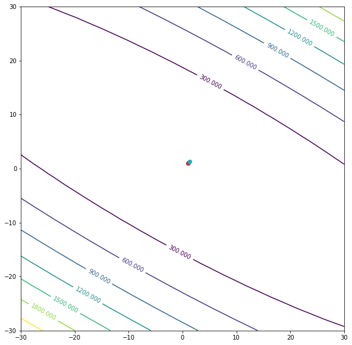

```python
X = np.abs(np.concatenate((X_random, interceptCol), axis=1))

# The noise column
disturbanceVector = np.random.normal(0,1,100)

#Learning rate set as 0.1
plot_graph_sse([1,1], 10, 0.1)
```

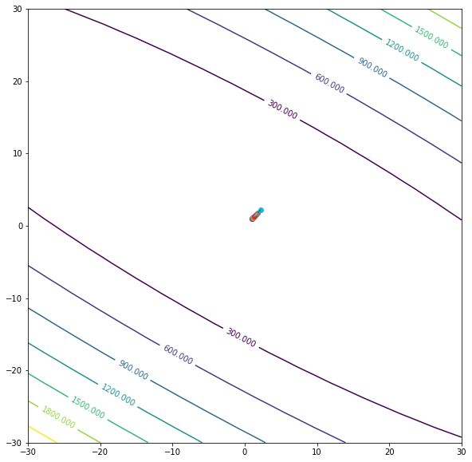

```python
#Learning rate set as 0.15
plot_graph_sse([1,1], 10, 0.15)
```

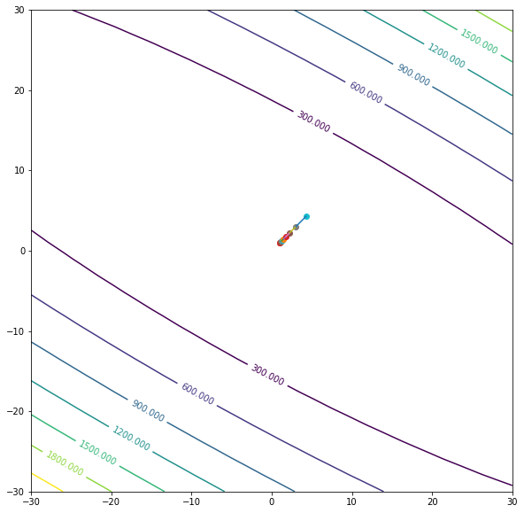

```python
#Learning rate set as 0.2
plot_graph_sse([1,1], 10, 0.2)
```

#### 1.6 Extra Challenge

```python
## function to implement 1D gradient function
def implement_gradient_lr(cur_x, stopping_criterion_e, iters, max_iters, rate):
    while np.linalg.norm(gradientf1D(cur_x)) > stopping_criterion_e and iters < max_iters:
        prev_x = cur_x #Store current x value in prev_x
        cur_x = cur_x - rate * gradientf1D(prev_x) #Grad descent
        iters = iters + 1 #iteration count
        if(cur_x - prev_x) < 0:  ##If move towards minimum increase the learning rate by 10%
            rate += rate * 0.1
        else: #Else decrease it by 25%
            rate = rate/4
        print("Iteration", iters, "\nX value is ", prev_x, "\nf(x) value is ", f1D(prev_x), "\nGradient value is ", gradientf1D(prev_x))
    print("The solution is ", prev_x, " and it took ", iters, " iterations")


#Change the starting value to 2, initial learning rate as 0.1
implement_gradient_lr(2, 0.01, 0, 1000, 0.1)
```

```
Iteration 1
X value is  2
f(x) value is  4
Gradient value is  4
Iteration 2
X value is  1.6
f(x) value is  2.5600000000000005
Gradient value is  3.2
Iteration 3
X value is  1.248
f(x) value is  1.557504
Gradient value is  2.496
Iteration 4
X value is  0.9459839999999999
f(x) value is  0.8948857282559999
Gradient value is  1.8919679999999999
Iteration 5
X value is  0.6941630591999999
f(x) value is  0.4818623527579025
Gradient value is  1.3883261183999998
Iteration 6
X value is  0.49089823220505585
f(x) value is  0.24098107438204894
Gradient value is  0.9817964644101117
Iteration 7
X value is  0.3327789298153429
f(x) value is  0.11074181612904492
Gradient value is  0.6655578596306858
Iteration 8
X value is  0.21487129507882313
f(x) value is  0.04616967344885068
Gradient value is  0.42974259015764626
Iteration 9
X value is  0.1311266216749734
f(x) value is  0.017194190911891605
Gradient value is  0.2622532433499468
Iteration 10
X value is  0.0749103098918581
f(x) value is  0.005611554528094213
Gradient value is  0.1498206197837162
Iteration 11
X value is  0.03958339144353783
f(x) value is  0.0015668448781723436
Gradient value is  0.07916678288707565
Iteration 12
X value is  0.019049566823165196
f(x) value is  0.00036288599615023616
Gradient value is  0.03809913364633039
Iteration 13
X value is  0.008179439353698905
f(x) value is  6.690322814083837e-05
Gradient value is  0.01635887870739781
The solution is  0.008179439353698905  and it took  13  iterations
```

```python
#Change the starting value to 2, initial learning rate as 0.01
implement_gradient_lr(2, 0.01, 0, 1000, 0.01)
```

```
Iteration 1
X value is  2
f(x) value is  4
Gradient value is  4
Iteration 2
X value is  1.96
f(x) value is  3.8415999999999997
Gradient value is  3.92
Iteration 3
X value is  1.91688
f(x) value is  3.6744289344
Gradient value is  3.83376
Iteration 4
X value is  1.8704915039999999
f(x) value is  3.4987384665361816
Gradient value is  3.7409830079999997
Iteration 5
X value is  1.8206990201635198
f(x) value is  3.314944922024401
Gradient value is  3.6413980403270396
Iteration 6
X value is  1.7673853114550917
f(x) value is  3.1236508391472113
Gradient value is  3.5347706229101834
Iteration 7
X value is  1.710457477096061
f(x) value is  2.925664780953822
Gradient value is  3.420914954192122
Iteration 8
X value is  1.6498538819244255
f(x) value is  2.722017831701096
Gradient value is  3.299707763848851
Iteration 9
X value is  1.5855519124802753
f(x) value is  2.5139748671698583
Gradient value is  3.1711038249605505
Iteration 10
X value is  1.517576485734939
f(x) value is  2.3030383900556073
Gradient value is  3.035152971469878
```

[output cut: 86 more lines]

```
f(x) value is  0.0011874098267707545
Gradient value is  0.0689176269693249
Iteration 33
X value is  0.0212305281242096
f(x) value is  0.0004507353244328548
Gradient value is  0.0424610562484192
Iteration 34
X value is  0.012265395504199804
f(x) value is  0.00015043992687444475
Gradient value is  0.024530791008399607
Iteration 35
X value is  0.006568081412079044
f(x) value is  4.3139693435698255e-05
Gradient value is  0.013136162824158089
The solution is  0.006568081412079044  and it took  35  iterations
```

**The adaptive learning rate does magic to the convergence. I tried implementing adaptive learning rate for 1D case. Doing that reduced the number of iterations to converge drastically. Without the adaptive algorithm, for learning rate 0.1 and 0.01, the number of iterations were 27 and 297 respectively. But with the adaptive algorithm, the iterations reduced to 13 and 35 for learning rates 0.1 and 0.01 respectively**